# 8_Uneigentliche_Integrale slides

## 8. Uneigentliche Integrale

**Beispiel:** $$f(x) = \frac{2}{x^2}$$

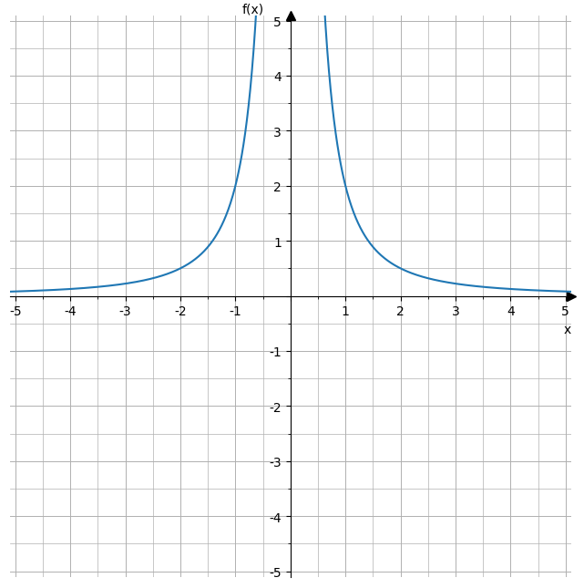

Berechnung des gerichteten Flächeninhalts zwischen Funktionsgraph von f mit der x-Achse auf dem Intervall $I=[1;2]$ $$\begin{align*} \int\limits_1^2 \frac{2}{x^2} dx &=\left[-\frac{2}{x}\right ]_1^2\\ &=-\frac{2}{2}+\frac{2}{1}\\ &= 1 \end{align*} $$

$$ \int\limits_0^1 \frac{2}{x^2} dx = ? \qquad \int\limits_1^\infty \frac{2}{x^2} dx = ? $$

**Idee:** Berechne den gerichteten Flächeninhalt mit einer Variablen Grenze $z$ und wende dann den Limes darauf an.

1. Berechnung des gerichteten Flächeninhalts:

$$ \begin{align*} \int\limits_z^1 \frac{2}{x^2} dx &= \left[-\frac{2}{x}\right ]_z^1\\ &=-\frac{2}{1}-\left(-\frac{2}{z}\right)\\ &= -2+\frac{2}{z} \end{align*} $$ 2. Anwendung des Limes: $$ \begin{align*} \lim_{z \to 0} -2+\frac{2}{z} = \infty \end{align*} $$ $\Rightarrow$ Der gerichtete Flächeninhalt $ \int\limits_z^1 \frac{2}{x^2} dx$ ist nicht endlich, er wächst unbegrenzt.

Analoge Betrachtung mit $ \int\limits_1^\infty \frac{2}{x^2} dx $:

1. Berechnung des gerichteten Flächeninhalts: $$ \begin{align*} \int\limits_1^z \frac{2}{x^2} dx &= \left[-\frac{2}{x}\right ]_1^z\\ &=-\frac{2}{z}-\left(-\frac{2}{1}\right)\\ &= -\frac{2}{z}+2 \end{align*} $$
2. Anwendung des Limes: $$ \begin{align*} \lim_{z \to \infty} -\frac{2}{z}+2 = 2 \end{align*} $$ $\Rightarrow$ Der gerichtete Flächeninhalt der unbegränzten Fläche ist 2.

Damit lässt sich schreiben: $$ \int\limits_1^\infty \frac{2}{x^2} dx = 2 $$

**Bemerkung:** Wenn es keine endlichen Flächeninhalt gibt, existiert das zugehörige Integral nicht

**Definition:**
Existiert der Grenzwert $$\lim_{z \to \infty} \int\limits_a^z f(x) dx $$ so schreibt man dafür $$\int\limits_a^\infty f(x) dx$$ und nennt ein solches Integral **uneigentliches Integral**.

**Bemerkungen:**

1. Analoges gilt, wenn c der oberen Grenze entspricht
2. Analoges gilt, wenn $-\infty$ eine Integrationsgrenze ist.